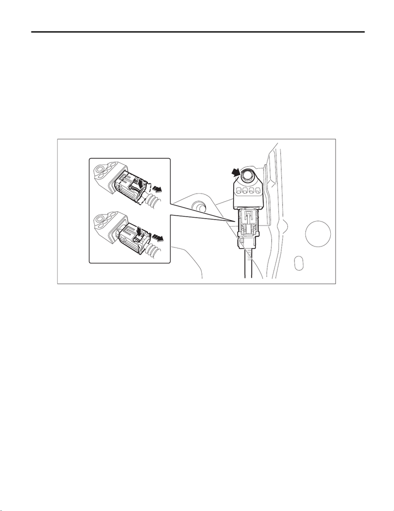

AB-50

Front Sub Sensor

AIRBAG SYSTEM

10.Front Sub Sensor

A: REMOVAL

1) Turn the ignition switch to OFF.

NT-5, BATTERY, NOTE, Note.>

NOTE:

For models other than STI model, disconnect the ground terminal from battery sensor.

Bumper.>

DURE, Airbag Connector.>

AB-02904

(2)

(1)

(3)

(4)

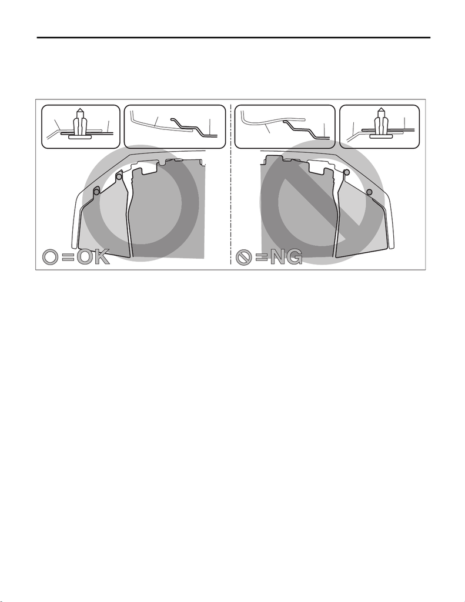

AB-51

Front Sub Sensor

AIRBAG SYSTEM

B: INSTALLATION

CAUTION:

• If the airbag has been activated, replace the front sub sensor with a new part.

• Install the bumper face - front so that the front end of the under cover (b) comes inside the bumper

face - front (a), and the front end of the mud guard (c) comes outside the bumper face - front (a).

• Before installing the bumper face, match the claws on the bracket - front bumper with the engaging

position of flange section on the bumper face side. If the engaging position is not correct, the flange

section may be broken or the clearance between fender panel and bumper face may not be uniform.

1) Before installation, inspect the following items and replace any faulty part with a new part.

• Front sub sensor damage

• Connector damage

2) Install the front sub sensor.

CAUTION:

• Do not reuse the bolt and nut.

Always replace with the specified new bolts and nuts.

• When installing the sensor, insert the set pin on the backside of the sensor into the hole on the

body side securely.

Tightening torque:

13 N·m (1.3 kgf-m, 9.6 ft-lb)

Bumper.>

4) Connect the battery ground terminal. <Ref. to NT-5, BATTERY, NOTE, Note.>

NOTE:

For models other than STI model, connect the ground terminal to battery sensor.

Fog Light Assembly.>

COM00138

(a)

(c)

(b)

(a)

(a)

(c)

(b)

(a)